# LAB 2 QC Notebook

### Package installation

If you haven’t already, install the required software. The commands in this section are run only once and should be commented after you have finished running them

```r
# Installing Bioconductor

if (!requireNamespace("BiocManager", quietly = TRUE))
  install.packages("BiocManager")
BiocManager::install()

# Installing dada2
BiocManager::install("dada2")

# Installing other packages needed
install.packages("ggplot2")
install.packages("vegan")
```

### Unpacking and sorting files

The following commands can be run in a terminal window (Mac) or in Rstudio console window. The tar archive should be unpacked in a suitable location (i.e., not the desktop). Preferably you have a robust file naming system for your research. For example, my research analysis are all kept in ~/Documents/research/. Each project has the following subdirectories: data/, analysis, scripts/. Scripts contains the R project. Other directories can be added as needed (e.g., manuscript, reports, ppt, etc.). This compartmentalizes the projects and helps keep things organized.

#### Decompress the and untar the archive (Mac)

First navigate to where you are storing your data. The decompress it. On Windows you will probably need 7zip or WinZip to decompress and unpack.

```r
cd <path_to_data>
tar -xvf path_592_files_biogeo.tar.gz
```

### Set the environment

#### Load required libraries

```r
library(dada2)
library(ggplot2)
options(stringsAsFactors = F)
```

### Import data

```r
path <- "/Users/cgaulke/unsynced_projects/raw_data/2022_10_10_path592_raw/"

filt.path <- "/Users/cgaulke/Documents/research/path592/lab_2_QC/filtered_data/" #filtered file directory make sure to update
```

Make sure everything is looking OK

```r
head(list.files(path))
```

```
[1] "F10GD_032522_AACTTTCAGGAG_L001_R1_001.fastq.gz"
[2] "F10GD_032522_AACTTTCAGGAG_L001_R2_001.fastq.gz"
[3] "F10GM_032522_ACACACCCTGAC_L001_R1_001.fastq.gz"
[4] "F10GM_032522_ACACACCCTGAC_L001_R2_001.fastq.gz"
[5] "F10GP_032522_CGAATACTGACA_L001_R1_001.fastq.gz"
[6] "F10GP_032522_CGAATACTGACA_L001_R2_001.fastq.gz"
```

Now make sure that that we are only going to be working with fastq files

```r
fnFs <- sort(list.files(path, pattern="_R1_001.fastq.gz", full.names = TRUE))
fnRs <- sort(list.files(path, pattern="_R2_001.fastq.gz", full.names = TRUE))
```

### Quality Control

First we will make sure nothing has gone wrong by checking that the number of forward and reverse read files are the same.

```r
length(fnFs) == length(fnRs)
```

```
[1] TRUE
```

We might also want to make some new, easier to work with, sample names for later

```r
sample.names <- sapply(strsplit(basename(fnFs), "_R1"), `[`, 1)
```

#### Plotting quality scores using dada2

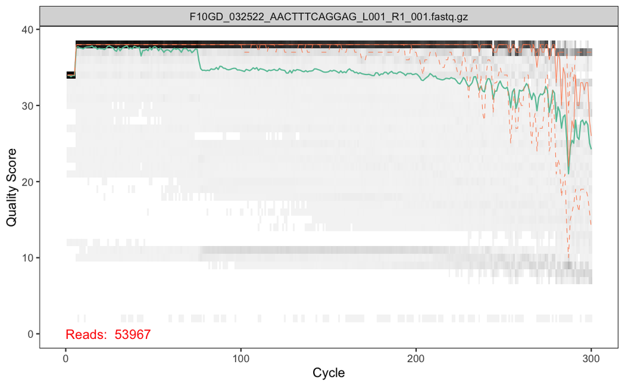

```r
plotQualityProfile(fnFs[1])
```

```
Warning: `guides(<scale> = FALSE)` is deprecated. Please use `guides(<scale> = "none")` instead.
```

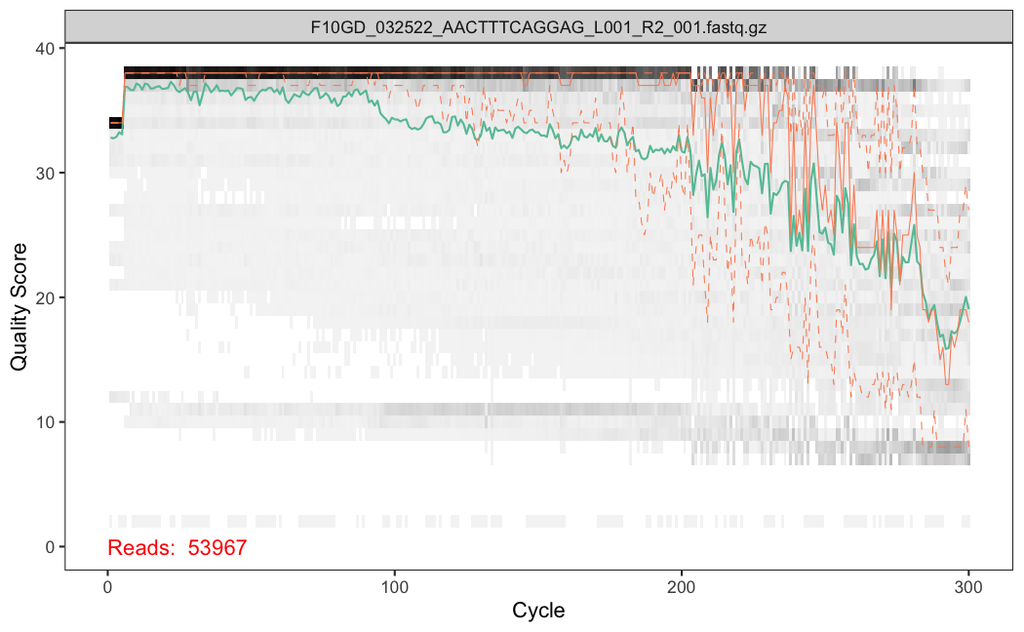

```r
plotQualityProfile(fnRs[1])
```

Warnings are generally OK, but should be read, errors on the otherhand usually need to be addressed.

Now we can plot all the read quality scores aggregated together (this might take a minute)

```r
fnFs_qual.plot <- plotQualityProfile(fnFs,aggregate = T)
```

```
Warning: `guides(<scale> = FALSE)` is deprecated. Please use `guides(<scale> = "none")` instead.
```

```r
fnRs_qual.plot <- plotQualityProfile(fnRs,aggregate = T)
```

While this is easier to look at than one plot at a time, it is still hard to see where the cutoffs should be. Since this is just wrapping ggplot2 code (see raw script), we can extend their code a bit

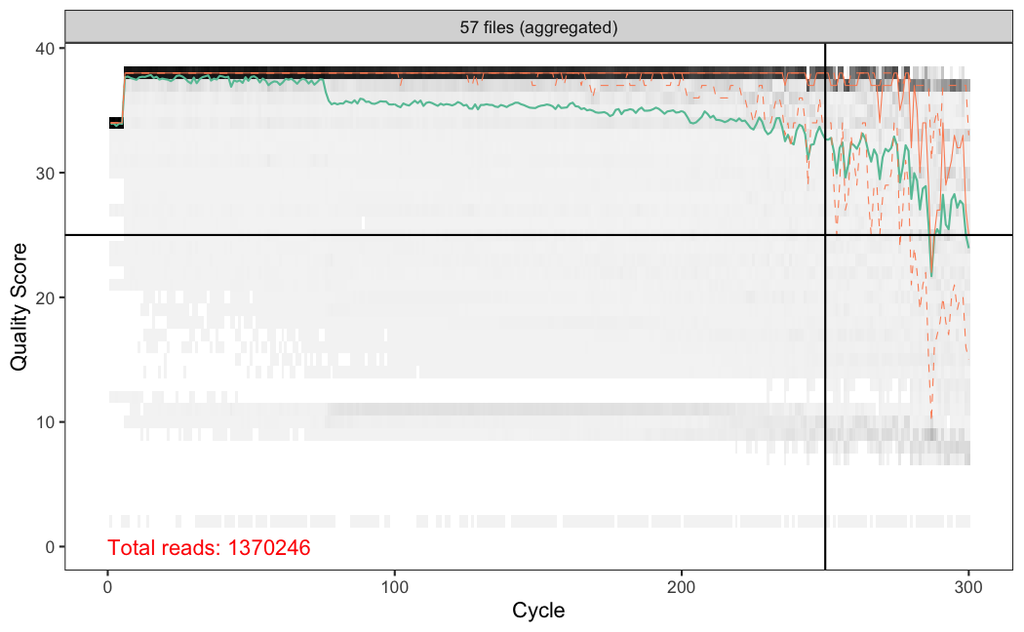

```r
fnFs_qual.plot + geom_hline(yintercept= 25) + geom_vline(xintercept = 250)
```

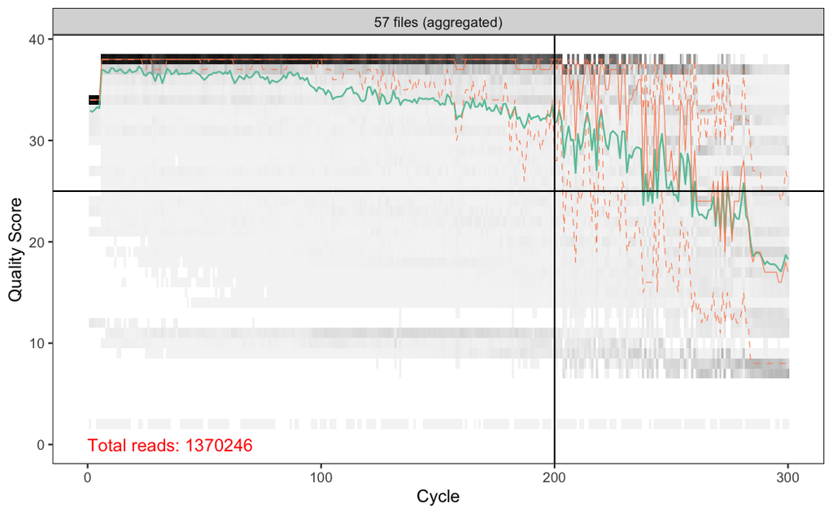

```r
fnRs_qual.plot + geom_hline(yintercept= 25) + geom_vline(xintercept = 200)
```

OK, so the reverse reads look a little worse than the forwards but the trimming thresholds (lines) wond eliminate overlap of the reads so we are OK.

#### Filtering reads

Next we want to set up names and locations for our filtered files that we will create later

```r
filtFs <- file.path(filt.path, "filtered",
                    paste0(sample.names, "_F_filt.fastq.gz"))

filtRs <- file.path(filt.path, "filtered",
                    paste0(sample.names, "_R_filt.fastq.gz"))
```

Next we will name them

```r
names(filtFs) <- sample.names
names(filtRs) <- sample.names
```

```r
filter.out <- filterAndTrim(fnFs, #paths to the input forward reads
                            filtFs, #paths to the output filtered forward reads
                            fnRs, #paths to the input reverse reads
                            filtRs, #paths to the output filtered reverse reads
                            truncLen=c(250,200), #R1 and R2 truncation lengths
                            maxN=0, #max allowable N's (ambiguous bases) in seq
                            maxEE=c(2,2), # max error allowed after filtering
                            truncQ=2, # truncate at first base with this score
                            rm.phix=TRUE, # remove phix reads
                            trimLeft = 10, # number of nt to trim from left
                            compress=TRUE, # gzip files
                            multithread=TRUE # OK for Mac, turn off on Windows
                            )
```

No Let’s check out the results

```r
head(filter.out)
```

```
                                               reads.in reads.out
F10GD_032522_AACTTTCAGGAG_L001_R1_001.fastq.gz    53967     43387
F10GM_032522_ACACACCCTGAC_L001_R1_001.fastq.gz    10081      6760
F10GP_032522_CGAATACTGACA_L001_R1_001.fastq.gz     4498      2678
F10GS_032522_AACCGCATAAGT_L001_R1_001.fastq.gz    40118     21685
F10SB_032522_AGATTCGCTCGA_L001_R1_001.fastq.gz    37212     31691
F1GD_032122_AAGGCGCTCCTT_L001_R1_001.fastq.gz     35448     32505
```

```r
colMeans(filter.out) #mean number of reads in and out of filtering
```

```
 reads.in reads.out
 24039.40  19921.68
```

```r
mean(1-(filter.out[,2]/filter.out[,1])) #mean % filtered reads
```

```
[1] 0.1863549
```

We can also dive into these numbers a little deeper

```r
fivenum(1-(filter.out[,2]/filter.out[,1])) #five number report for % filtered
```

```
F8GD_032522_CGGCCAGAAGCA_L001_R1_001.fastq.gz F1GM_032122_CGCGCAAGTATT_L001_R1_001.fastq.gz
                                   0.05710446                                    0.08961702
F1GP_032122_CCTCGCATGACC_L001_R1_001.fastq.gz F3GM_032122_ACTAAGTACCCG_L001_R1_001.fastq.gz
                                   0.14078695                                    0.21935123
F3SS_032122_GGACAAGTGCGA_L001_R1_001.fastq.gz
                                   0.62975414
```

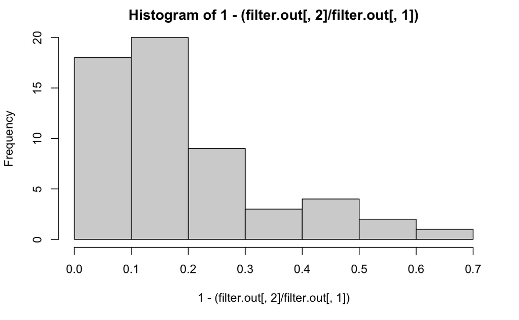

```r
hist(1-(filter.out[,2]/filter.out[,1]))  # hist #mean % filtered reads
```

Since some libraries look like there is a higher level of filtration than others lets take a closer look at which ones are not great.

```r
tail(sort(
  1-(filter.out[,2]/filter.out[,1])
  ),  n =10
)
```

```
 F9SB_032522_AAGTCACACACA_L001_R1_001.fastq.gz  F4SB_032322_CACCCTTGCGAC_L001_R1_001.fastq.gz
                                     0.3204055                                      0.3212244
F10GM_032522_ACACACCCTGAC_L001_R1_001.fastq.gz F10GP_032522_CGAATACTGACA_L001_R1_001.fastq.gz
                                     0.3294316                                      0.4046243
 F3SB_032122_GTTAACTTACTA_L001_R1_001.fastq.gz  F4SS_032322_GTTGTTCTGGGA_L001_R1_001.fastq.gz
                                     0.4278786                                      0.4426796
F10GS_032522_AACCGCATAAGT_L001_R1_001.fastq.gz  F4GP_032122_CTGATGTACACG_L001_R1_001.fastq.gz
                                     0.4594696                                      0.5119294
 F3GS_032122_GCGAGGAAGTCC_L001_R1_001.fastq.gz  F3SS_032122_GGACAAGTGCGA_L001_R1_001.fastq.gz
                                     0.5971425                                      0.6297541
```